# Budowa rankingu ekologiczności polskich miast za pomocą metod porządkowania liniowego

Artur Karamon

15 grudnia 2018

## Wprowadzenie

Projekt ten porusza temat konstruowania rankingów z wykorzystaniem różnych metod porządkowania liniowego. Całość pracy składa się z dwóch części. Pierwszą z nich jest stworzenie funkcji pozwalającej na wykonanie takich rankingów. Druga część zawiera natomiast użycie uprzednio zrobionej funkcji na wybranych danych oraz wizualizacja uzyskanych wyników.  
Dane wykorzystane w pracy dotyczą zagadnienia szarokopojętej ekologii oraz ochrony środowiska w największych polskich miastach. Pochodzą one z 2017 roku z Banku Danych Lokalnych i obejmują:

- udział terenów zielonych w stosunku do całkowitej powierzchni miasta w procentach(**udzial_terenow_ziel**)
- liczbę pojazdów zasilanych paliwami płynnymi, tj.benzyna i olej napędowy, zarejestrowanych w mieście(**pojazdy_paliwa_plynne**)
- zużycie wody w mieście w ciągu roku w dekmetrach sześciennych(**zuzycie_wody**)
- wyworzone odpady w ciągu roku, które nie zostały zneutralizowane, tj. nie zostały poddane odzyskowi lub unieszkodliwione, w tys. ton(**odpady_niezneutralizowane**)
- udział odpadów zbieranych selektywnie w stosunku do ogółu w procentach(**odpady_selektywnie_do_ogolu**)
- wskaźnik określający ładunek zanieczyszczeń w ściekach po oczyszczeniu, konstruowany jako iloraz Chzt-chemicznego zapotrzebowania na tlen oraz Bzt5-bochemicznego zapotrzebowania na tlen(**wsk_ladunek_scieki**)
- wskaźnik jakości powietrza, powstały przez zsumowanie ilorazów średnich wartości rocznych SO2, NO2, PM10 zawartych w powietrzu do odpowiednich dla nich wartości krytycznych(**wsk_jakosc_powietrza**)
- wydatki budżetu miasta na gospodarkę komunalną i ochronę środowiska w złotówkach w ciągu roku(**wydatki_ochrona_srod**)

Zmienne pojazdy_paliwa_plynne, zuzycie_wody, odpady_niezneutralizowane, wydatki_ochrona_srod przeliczono w stosunku do 1000 mieszkańców miasta w celu umożliwienia porównywania ich wartości w różnych miastach oraz przeprowadzono kilka innych operacji, aby uporządkować zbiór danych.(usunięto obserwacje zawierające braki w danych, wyselekcjonowano 25 najliczniejszych miast)  
Określono również charakter wszystkich zmiennych pod względem wpływu na ekologię oraz ochronę środowiska w mieście. Powstałe grupy:

- **stymulanty:** udzial_terenow_ziel, odpady_selektywnie_do_ogolu, wydatki_ochrona_srod; im większa wartość, tym lepiej wpływa na ekologię i ochronę środowiska
- **destymulanty:** pojazdy_paliwa_plynne, zuzycie_wody, odpady_niezneutralizowane, wsk_jakosc_powietrza; im większa wartość, tym gorzej wpływa na ekologię i ochronę środowiska
- **nominanty:** wsk_ladunek_scieki; im wartość jest bardziej oddalona od wartości optymalnej(wartość optymalna dla tego wskaźnika wg. opracowań eksperckich to 6), tym gorzej wpływa na ekologię i ochronę środowiska

|  | udzial_terenow _ziel | pojazdy_ paliwa_ plynne_ | zuzycie_ wody | odpady_ niezneutralizowane_ | odpady_ selektywnie_ do_ogolu | wsk_ladunek_ scieki | wsk_jakosc_ powietrza | wydatki_ ochrona_ srodowiska_ |
| --- | --- | --- | --- | --- | --- | --- | --- | --- |
| Wroclaw | 6.6 | 631.73 | 88.72 | 0.49 | 29.5 | 11.41 | 0.08 | 606410.7 |
| Bydgoszcz | 7.8 | 579.82 | 59.38 | 0.28 | 28.4 | 7.38 | 0.10 | 374314.5 |
| Torun | 3.4 | 528.48 | 50.11 | 0.10 | 19.4 | 11.75 | 0.07 | 295175.0 |
| Lublin | 5.4 | 527.79 | 55.49 | 0.25 | 26.2 | 5.71 | 0.08 | 327836.8 |
| Zielona Gora | 0.7 | 585.55 | 50.29 | 0.49 | 18.6 | 6.44 | 0.06 | 474747.1 |
| Lodz | 5.8 | 527.37 | 54.74 | 0.45 | 27.8 | 5.37 | 0.09 | 345896.8 |
| Krakow | 5.3 | 617.60 | 70.22 | 0.81 | 36.2 | 5.70 | 0.14 | 702764.6 |
| Radom | 4.8 | 486.16 | 43.03 | 0.24 | 27.3 | 8.06 | 0.08 | 239148.1 |
| Warszawa | 6.2 | 755.46 | 149.95 | 0.56 | 24.2 | 6.43 | 0.10 | 342319.9 |
| Rzeszow | 2.8 | 571.45 | 57.17 | 0.37 | 28.4 | 8.34 | 0.08 | 523396.3 |
| Bialystok | 5.0 | 429.37 | 47.28 | 1.24 | 40.6 | 9.89 | 0.05 | 267674.6 |
| Gdansk | 3.2 | 615.46 | 120.31 | 0.48 | 27.6 | 12.34 | 0.06 | 513674.6 |
| Bielsko Biala | 1.7 | 661.29 | 55.15 | 0.74 | 88.4 | 6.65 | 0.09 | 342582.6 |
| Bytom | 4.3 | 448.04 | 44.94 | 1.98 | 26.0 | 6.98 | 0.10 | 454430.4 |
| Czestochowa | 3.2 | 538.83 | 71.23 | 1.04 | 18.1 | 9.78 | 0.12 | 348312.5 |
| Gliwice | 2.9 | 607.45 | 56.70 | 5.18 | 25.7 | 3.69 | 0.11 | 520409.4 |
| Katowice | 3.6 | 761.92 | 67.51 | 3.04 | 21.5 | 12.33 | 0.15 | 437232.6 |
| Ruda Slaska | 4.2 | 469.94 | 71.42 | 5.36 | 20.2 | 9.48 | 0.12 | 350796.5 |
| Rybnik | 2.1 | 542.55 | 110.04 | 9.56 | 27.5 | 6.00 | 0.12 | 508875.8 |
| Sosnowiec | 4.9 | 516.06 | 43.34 | 0.48 | 91.7 | 7.43 | 0.11 | 456448.2 |
| Tychy | 4.8 | 599.57 | 80.93 | 2.18 | 31.9 | 5.55 | 0.11 | 341286.2 |
| Zabrze | 4.6 | 475.44 | 39.77 | 0.25 | 33.2 | 9.76 | 0.12 | 240984.9 |
| Olsztyn | 4.2 | 551.82 | 68.49 | 0.37 | 21.3 | 7.15 | 0.06 | 442455.5 |
| Poznan | 4.0 | 772.09 | 65.39 | 0.85 | 27.9 | 11.40 | 0.08 | 300634.9 |
| Szczecin | 1.9 | 563.49 | 274.89 | 0.28 | 21.7 | 7.78 | 0.06 | 452255.7 |

Następnie obliczono podstawowe statystyki opisowe dla zbioru, takie jak średnia, mediana, odchylenie standardowe, kurtoza itp., a także wygenerowane wykresy pudełkowe oraz histogramy w celu jego lepszego scharakteryzowania.  
Tabela statystyk opisowych dla każdej zmiennej:

|  | n | mean | sd | median | min | max | range | skew | kurtosis | se |
| --- | --- | --- | --- | --- | --- | --- | --- | --- | --- | --- |
| udzial_terenow_ziel | 25 | 4.14 | 1.64 | 4.20 | 0.70 | 7.80 | 7.10 | 0.02 | -0.40 | 0.33 |
| pojazdy_paliwa_plynne | 25 | 574.59 | 91.65 | 563.49 | 429.37 | 772.09 | 342.72 | 0.66 | -0.22 | 18.33 |
| zuzycie_wody | 25 | 75.86 | 48.97 | 59.38 | 39.77 | 274.89 | 235.12 | 2.78 | 8.21 | 9.79 |
| odpady_niezneutralizowane | 25 | 1.48 | 2.20 | 0.49 | 0.10 | 9.56 | 9.47 | 2.31 | 4.97 | 0.44 |
| odpady_selektywnie_do_ogolu | 25 | 31.57 | 18.41 | 27.50 | 18.10 | 91.70 | 73.60 | 2.50 | 5.24 | 3.68 |
| wsk_ladunek_scieki | 25 | 8.11 | 2.43 | 7.43 | 3.69 | 12.34 | 8.65 | 0.31 | -1.09 | 0.49 |
| wsk_jakosc_powietrza | 25 | 0.09 | 0.03 | 0.09 | 0.05 | 0.15 | 0.10 | 0.21 | -0.89 | 0.01 |
| wydatki_ochrona_srod | 25 | 408402.57 | 115136.18 | 374314.50 | 239148.14 | 702764.61 | 463616.47 | 0.57 | -0.25 | 23027.24 |

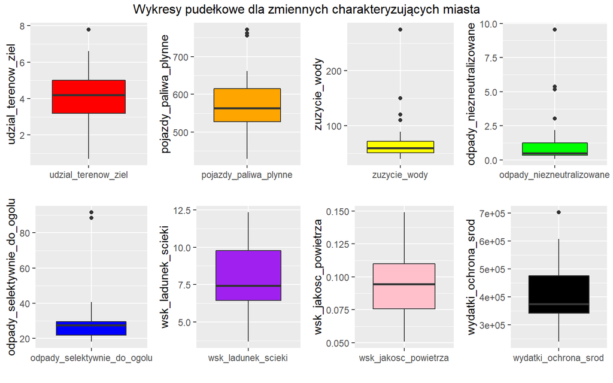

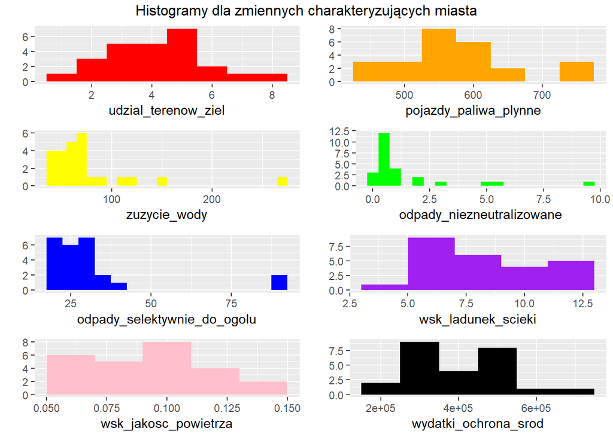

## Analiza i wizualizacja

Do przeprowadznia wszystkich badań konieczne jest wczytanie odpowiednich bibliotek.

```r
# ładowanie bibliotek
library("TSdist")
library("ggplot2")
library("dplyr")
library("tidyr")
library("psych")
library("stats")
library("cluster")
library("kableExtra")
library("gridExtra")
library("maps")
library("SmarterPoland")
library("ggrepel")
```

### Część I

W pierwszej części projektu stworzono funkcję pozwalającą na generowanie rankingów metodą porządkowania liniowego na podstawie ramki danych. Funkcja ranking() przyjmuje następujące argumenty:

- **dframe** - ramka danych, argument obowiązkowy
- **method** - metoda(“hellwig”,“stand_sum”, “suma_rang”), domyślnie hellwig, argument opcjonalny
- **var_types_vect** - wektor zawierający charakter zmiennych znajdujących się w każdej kolumnie(s-stymulanta,d-destymulanta,n-nominanta), domyślnie wszystkie stymulanty, argument opcjonalny
- **optimum_vect** - wektor wartości optymalnych, argument opcjonalny
- **weight_vect** - wektor wag dla zmiennych w każdej kolumnie,domyślnie wszystkie wagi jednakowe, argument opcjonalny
- **weight_auto** - wartość logiczna(TRUE/FALSE), określająca czy wagi zmiennych mają zostać wygenerowane wprost proporcjonalnie do stopnia informacyjności cech automatycznie, domyślnie FALSE, argument opcjonalny.

Funkcja ranking() zwraca listę zawierającą trzy ramki danych: ramkę nieuporządkowaną, ale z przypisanymi rangami, ramką uporządkowaną oraz ramkę przejściową zawierającą standaryzowane zmienne oraz wykonywane obliczenia.

```r
ranking<-function(dframe, method="hellwig", var_types_vect = rep("s",ncol(dframe)), optimum_vect,
                  weight_vect = rep(1,ncol(dframe)),weight_auto=FALSE){

  dframe_transform<-dframe
  i_opt<-0
  #zamiana nominant i destymulant na stymulanty
  for (i_col in 1:ncol(dframe)) {
    if (var_types_vect[i_col]=="d") {
      dframe_transform[,i_col]<--dframe_transform[,i_col]
    }
    if (var_types_vect[i_col]=="n") {
      i_opt<-i_opt+1
      dframe_transform[,i_col]<--abs(optimum_vect[i_opt]-dframe_transform[,i_col])
    }
  }
  #skalowanie wartosci zmiennych
  dframe_transform<-as.data.frame(scale(dframe_transform))

  #nadawanie wag zmiennych, w przypadku wyboru opcji automatycznego doboru
  if (weight_auto==TRUE) {
    sd_mean<-apply(piwo,2,sd)/apply(piwo,2,mean)
    weight_vect<-sd_mean/sum(sd_mean)
  }

  #porzadkowanie metoda hellwiga
  if(method=="hellwig"){
    #nalozenie wag na standaryzowane dane
    dframe_transform<-dframe_transform*as.list(weight_vect)
    #ustalenie wektora zawierającego najlepsze wartosci("wzor")
    dframe_transform_max<-apply(dframe_transform,2,max)
    distance_vect<-NULL
    #obliczenie odleglosci euklidesowych kazdej z oberwacji od "wzoru"
    for (i in 1:nrow(dframe_transform)) {
      distance<-EuclideanDistance(as.numeric(dframe_transform[i,]),dframe_transform_max)
      distance_vect<-c(distance_vect,distance)
    }
    dframe_transform<-cbind(dframe_transform,EDist=distance_vect)
    #wyznaczenie miary dla kazdego z obiektow
    hellwig_dframe<-1-(dframe_transform[,ncol(dframe_transform)]/(mean(dframe_transform[,ncol(dframe_transform)]) + 2 * sd(dframe_transform[,ncol(dframe_transform)])))
    dframe_transform<-cbind(dframe_transform,hellwig = -hellwig_dframe)

    #dopisanie pozycji do kazdego obiektu
    dframe_unordered<-cbind(dframe,hellwig = hellwig_dframe,rank=round(rank(-hellwig_dframe, ties.method = "first"),digits = 0))
    #uprzadkowanie wg. rankingu
    dframe_rank<-dframe_unordered[order(dframe_unordered$rank),]

  }
  #porzadkowanie metoda standaryzowanych sum
  if(method=="stand_sum"){
    #nalozenie wag na standaryzowane dane
    dframe_transform<-dframe_transform*as.list(weight_vect)

    #uzyskanie wektora sum dla kazdej obserwacji, a nastepnie standaryzacja sum
    stand_sum_vect<-apply(dframe_transform,1,sum)
    stand_sum_vect<-(stand_sum_vect-min(stand_sum_vect))/(max(stand_sum_vect-min(stand_sum_vect)))
    dframe_transform<-cbind(dframe_transform,stand_sum = stand_sum_vect)

    #dopisanie pozycji do kazdego obiektu
    dframe_unordered<-cbind(dframe,stand_sum = stand_sum_vect,rank=round(rank(-stand_sum_vect, ties.method = "first"),digits = 0))
    #uprzadkowanie wg. rankingu
    dframe_rank<-dframe_unordered[order(dframe_unordered$rank),]
  }
  #porzadkowanie metoda sumy rang
  if(method=="suma_rang"){
    #utworzenie dodatkowych kolumn zawierajacych rangi wg. kazdej ze zmiennych
    for (i_col in 1:ncol(dframe)) {
      new_col<-paste0("rank",i_col)
      dframe_transform<-cbind(dframe_transform,rank(-dframe_transform[,i_col],ties.method = "average"))
      colnames(dframe_transform)[i_col+ncol(dframe)]<-new_col
    }
    #nalozenie wag na rangi
    dframe_transform[,(ncol(dframe)+1):ncol(dframe_transform)]<-dframe_transform[,(ncol(dframe)+1):ncol(dframe_transform)]*as.list(weight_vect)

    #zsumowanie rang
    rank_sum_vect<-apply(dframe_transform[,(ncol(dframe)+1):ncol(dframe_transform)],1,mean)
    dframe_transform<-cbind(dframe_transform,rank_sum = -rank_sum_vect)

    #dopisanie pozycji do kazdego obiektu
    dframe_unordered<-cbind(dframe,rank_sum = rank_sum_vect,rank=round(rank(rank_sum_vect, ties.method = "first"),digits = 0))
    #uprzadkowanie wg. rankingu
    dframe_rank<-dframe_unordered[order(dframe_unordered$rank),]
  }
  #zwrocenie wejsciowej ramki danych z dodanymi rangami dla kazdej obserwacji
  return(list(dframe_unordered,dframe_rank,dframe_transform))
}
```

### Część II - Budowanie rankingu ekologiczności największych polskich miast

W tej części zbudowano ranking największych polskich miast pod względem ekologii oraz ochrony środowiska z wykorzystaniem funkcji ranking(). Użyto do tego celu różnych metod, tj. metody Hellwiga, metody standaryzowanych sum oraz metody sumy rang, aby jak najpełniej zobrazowować ogólną kolejność miast, a także porównać otrzymymane wyniki.

**Hipoteza badawcza:**  
Miasta południowej Polski, które w dużej mierze wykorzystują przemysł wydobywczy oraz znajdują się w bliskiej odległości między sobą osiągają gorsze wyniki w rankingu ekologiczności w porównaniu z miastami nadmorskimi, gdyż warunki te negatywnie wpływają na rozpatrywane czynniki opisujące miasta w badaniu.

Dane, na których pracowano przedstawia poniższa tabela. Już na jej podstawie można zuważyć, które miasta osiągają najwyższe wartości, a które najniższe.

| miasto | udzial_terenow _ziel | pojazdy_ paliwa_ plynne_ | zuzycie_ wody | odpady_ niezneutralizowane_ | odpady_ selektywnie_ do_ogolu | wsk_ladunek_ scieki | wsk_jakosc_ powietrza | wydatki_ ochrona_ srodowiska_ |
| --- | --- | --- | --- | --- | --- | --- | --- | --- |
| Wroclaw | 6.6 | 631.73 | 88.72 | 0.49 | 29.5 | 11.41 | 0.08 | 606410.73 |
| Bydgoszcz | 7.8 | 579.82 | 59.38 | 0.28 | 28.4 | 7.38 | 0.1 | 374314.5 |
| Torun | 3.4 | 528.48 | 50.11 | 0.1 | 19.4 | 11.75 | 0.07 | 295174.99 |
| Lublin | 5.4 | 527.79 | 55.49 | 0.25 | 26.2 | 5.71 | 0.08 | 327836.81 |
| Zielona Gora | 0.7 | 585.55 | 50.29 | 0.49 | 18.6 | 6.44 | 0.06 | 474747.06 |
| Lodz | 5.8 | 527.37 | 54.74 | 0.45 | 27.8 | 5.37 | 0.09 | 345896.84 |
| Krakow | 5.3 | 617.6 | 70.22 | 0.81 | 36.2 | 5.7 | 0.14 | 702764.61 |
| Radom | 4.8 | 486.16 | 43.03 | 0.24 | 27.3 | 8.06 | 0.08 | 239148.14 |
| Warszawa | 6.2 | 755.46 | 149.95 | 0.56 | 24.2 | 6.43 | 0.1 | 342319.91 |
| Rzeszow | 2.8 | 571.45 | 57.17 | 0.37 | 28.4 | 8.34 | 0.08 | 523396.32 |
| Bialystok | 5 | 429.37 | 47.28 | 1.24 | 40.6 | 9.89 | 0.05 | 267674.59 |
| Gdansk | 3.2 | 615.46 | 120.31 | 0.48 | 27.6 | 12.34 | 0.06 | 513674.61 |
| Bielsko Biala | 1.7 | 661.29 | 55.15 | 0.74 | 88.4 | 6.65 | 0.09 | 342582.57 |
| Bytom | 4.3 | 448.04 | 44.94 | 1.98 | 26 | 6.98 | 0.1 | 454430.37 |
| Czestochowa | 3.2 | 538.83 | 71.23 | 1.04 | 18.1 | 9.78 | 0.12 | 348312.47 |
| Gliwice | 2.9 | 607.45 | 56.7 | 5.18 | 25.7 | 3.69 | 0.11 | 520409.4 |
| Katowice | 3.6 | 761.92 | 67.51 | 3.04 | 21.5 | 12.33 | 0.15 | 437232.58 |
| Ruda Slaska | 4.2 | 469.94 | 71.42 | 5.36 | 20.2 | 9.48 | 0.12 | 350796.49 |
| Rybnik | 2.1 | 542.55 | 110.04 | 9.56 | 27.5 | 6 | 0.12 | 508875.77 |
| Sosnowiec | 4.9 | 516.06 | 43.34 | 0.48 | 91.7 | 7.43 | 0.11 | 456448.24 |
| Tychy | 4.8 | 599.57 | 80.93 | 2.18 | 31.9 | 5.55 | 0.11 | 341286.19 |
| Zabrze | 4.6 | 475.44 | 39.77 | 0.25 | 33.2 | 9.76 | 0.12 | 240984.9 |
| Olsztyn | 4.2 | 551.82 | 68.49 | 0.37 | 21.3 | 7.15 | 0.06 | 442455.49 |
| Poznan | 4 | 772.09 | 65.39 | 0.85 | 27.9 | 11.4 | 0.08 | 300634.9 |
| Szczecin | 1.9 | 563.49 | 274.89 | 0.28 | 21.7 | 7.78 | 0.06 | 452255.7 |

Na początku wygenerowane zostały 3 rankingi z użyciem metod: Hellwiga, standaryzowanych sum oraz sumy rang.

```r
ranking_hellwig<-ranking(dane_wsk, "hellwig",c("s","d","d","d","s","n","d","s"),c(6))
ranking_stand_sum<-ranking(dane_wsk, "stand_sum",c("s","d","d","d","s","n","d","s"),c(6))
ranking_suma_rang<-ranking(dane_wsk, "suma_rang",c("s","d","d","d","s","n","d","s"),c(6))
```

Zmienne po zamianie na stymulanty oraz standaryzacji pozwalają otrzymać wiele informacji najlepszych wartościach w danej kategorii. Już w tym miejscu można wskazać kilku faworytów.

| miasto | udzial_terenow _ziel | pojazdy_ paliwa_ plynne_ | zuzycie_ wody | odpady_ niezneutralizowane_ | odpady_ selektywnie_ do_ogolu | wsk_ladunek_ scieki | wsk_jakosc_ powietrza | wydatki_ ochrona_ srodowiska_ |
| --- | --- | --- | --- | --- | --- | --- | --- | --- |
| Wroclaw | 1.5 | -0.62 | -0.26 | 0.45 | -0.11 | -1.42 | 0.43 | 1.72 |
| Bydgoszcz | 2.23 | -0.06 | 0.34 | 0.54 | -0.17 | 0.5 | -0.37 | -0.3 |
| Torun | -0.45 | 0.5 | 0.53 | 0.63 | -0.66 | -1.58 | 0.96 | -0.98 |
| Lublin | 0.77 | 0.51 | 0.42 | 0.56 | -0.29 | 1.02 | 0.51 | -0.7 |
| Zielona Gora | -2.09 | -0.12 | 0.52 | 0.45 | -0.7 | 0.95 | 1.1 | 0.58 |
| Lodz | 1.01 | 0.52 | 0.43 | 0.47 | -0.2 | 0.86 | -0.04 | -0.54 |
| Krakow | 0.71 | -0.47 | 0.12 | 0.31 | 0.25 | 1.02 | -1.8 | 2.56 |
| Radom | 0.4 | 0.96 | 0.67 | 0.56 | -0.23 | 0.18 | 0.43 | -1.47 |
| Warszawa | 1.26 | -1.97 | -1.51 | 0.42 | -0.4 | 0.95 | -0.4 | -0.57 |
| Rzeszow | -0.81 | 0.03 | 0.38 | 0.5 | -0.17 | 0.04 | 0.66 | 1 |
| Bialystok | 0.53 | 1.58 | 0.58 | 0.11 | 0.49 | -0.7 | 1.61 | -1.22 |
| Gdansk | -0.57 | -0.45 | -0.91 | 0.45 | -0.22 | -1.86 | 1.43 | 0.91 |
| Bielsko Biala | -1.48 | -0.95 | 0.42 | 0.34 | 3.09 | 0.85 | 0.06 | -0.57 |
| Bytom | 0.1 | 1.38 | 0.63 | -0.23 | -0.3 | 0.69 | -0.17 | 0.4 |
| Czestochowa | -0.57 | 0.39 | 0.09 | 0.2 | -0.73 | -0.64 | -0.89 | -0.52 |
| Gliwice | -0.75 | -0.36 | 0.39 | -1.68 | -0.32 | 0.06 | -0.62 | 0.97 |
| Katowice | -0.33 | -2.04 | 0.17 | -0.71 | -0.55 | -1.86 | -2.1 | 0.25 |
| Ruda Slaska | 0.04 | 1.14 | 0.09 | -1.76 | -0.62 | -0.5 | -1.07 | -0.5 |
| Rybnik | -1.24 | 0.35 | -0.7 | -3.67 | -0.22 | 1.16 | -1.04 | 0.87 |
| Sosnowiec | 0.47 | 0.64 | 0.66 | 0.45 | 3.27 | 0.48 | -0.52 | 0.42 |
| Tychy | 0.4 | -0.27 | -0.1 | -0.32 | 0.02 | 0.94 | -0.5 | -0.58 |
| Zabrze | 0.28 | 1.08 | 0.74 | 0.56 | 0.09 | -0.63 | -0.83 | -1.45 |
| Olsztyn | 0.04 | 0.25 | 0.15 | 0.51 | -0.56 | 0.61 | 1.36 | 0.3 |
| Poznan | -0.08 | -2.15 | 0.21 | 0.29 | -0.2 | -1.42 | 0.67 | -0.94 |
| Szczecin | -1.36 | 0.12 | -4.06 | 0.54 | -0.54 | 0.31 | 1.13 | 0.38 |

Po zakończeniu porządkowania możliwe jest zwizualizowanie otrzymanych wynikiów.  
Tabela porównawcza, kolejność dla różnych metod:

| pozycja | hellwig | miasto | stand_sum | miasto | suma_rang | miasto |
| --- | --- | --- | --- | --- | --- | --- |
| 1 | 0.54 | Sosnowiec | 1.00 | Sosnowiec | 8.38 | Sosnowiec |
| 2 | 0.36 | Bytom | 0.78 | Bialystok | 9.12 | Lublin |
| 3 | 0.36 | Wroclaw | 0.76 | Lublin | 9.38 | Lodz |
| 4 | 0.35 | Olsztyn | 0.76 | Bydgoszcz | 9.88 | Bialystok |
| 5 | 0.35 | Bydgoszcz | 0.76 | Krakow | 10.19 | Bydgoszcz |
| 6 | 0.35 | Lodz | 0.75 | Olsztyn | 10.31 | Radom |
| 7 | 0.34 | Krakow | 0.74 | Bytom | 10.75 | Bytom |
| 8 | 0.34 | Lublin | 0.74 | Lodz | 10.75 | Zabrze |
| 9 | 0.34 | Rzeszow | 0.68 | Bielsko Biala | 11.31 | Rzeszow |
| 10 | 0.33 | Bialystok | 0.68 | Wroclaw | 11.38 | Krakow |
| 11 | 0.29 | Bielsko Biala | 0.68 | Rzeszow | 11.69 | Olsztyn |
| 12 | 0.28 | Tychy | 0.67 | Radom | 12.12 | Wroclaw |
| 13 | 0.27 | Radom | 0.60 | Zielona Gora | 12.75 | Zielona Gora |
| 14 | 0.22 | Gdansk | 0.54 | Zabrze | 13.38 | Torun |
| 15 | 0.22 | Zabrze | 0.52 | Tychy | 13.62 | Bielsko Biala |
| 16 | 0.21 | Gliwice | 0.47 | Torun | 14.12 | Szczecin |
| 17 | 0.19 | Zielona Gora | 0.46 | Gdansk | 14.31 | Gdansk |
| 18 | 0.17 | Torun | 0.38 | Warszawa | 14.44 | Tychy |
| 19 | 0.16 | Czestochowa | 0.37 | Gliwice | 15.00 | Warszawa |
| 20 | 0.16 | Ruda Slaska | 0.35 | Czestochowa | 15.25 | Rybnik |
| 21 | 0.15 | Warszawa | 0.31 | Ruda Slaska | 15.88 | Gliwice |
| 22 | 0.10 | Poznan | 0.28 | Szczecin | 16.25 | Poznan |
| 23 | 0.06 | Rybnik | 0.27 | Poznan | 16.94 | Ruda Slaska |
| 24 | 0.05 | Szczecin | 0.21 | Rybnik | 18.06 | Czestochowa |
| 25 | 0.00 | Katowice | 0.00 | Katowice | 19.75 | Katowice |

Drugi sposób przedstawienia rezultatów to wykres, na którym można porównać jak dane miasto wypadło w każdym rankingu.

[figure not shown]

Stworzono również mapkę, na której kolory znaczników oznaczają uśrednione miejsca w rankingu pochodzące z trzech metod.

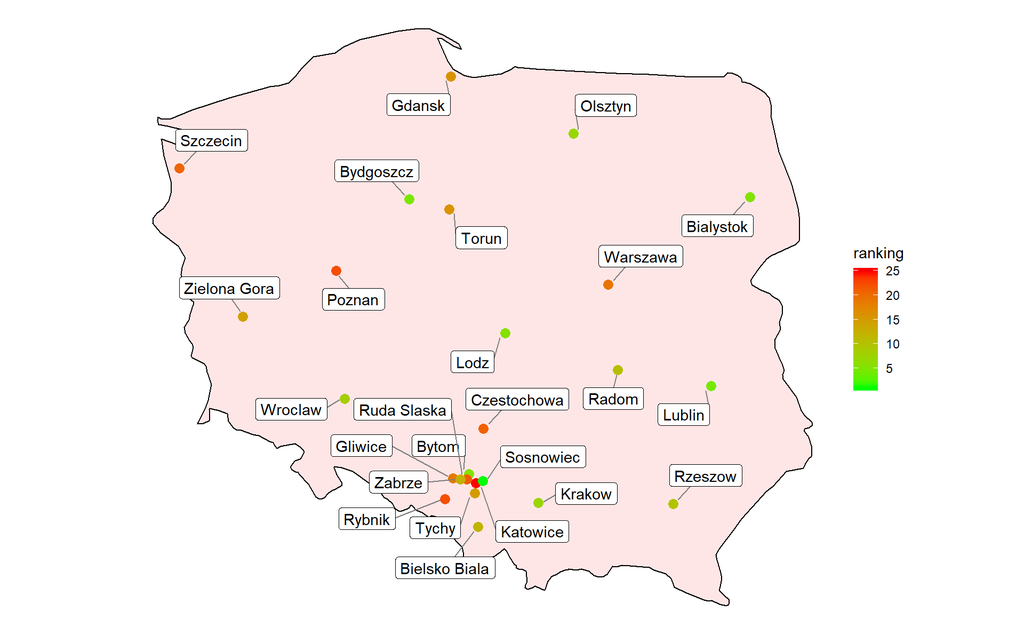

## Zakończenie

**Wnioski:**  
Podsumowując, wyniki uzyskane różnymi metodami zawierają istotne róznice. Jednakże pozycja wielu miast nie ulega zmianie lub jest dość podobna. Najlepszym przykładem na to są pierwsze i ostatnie miasto w rankingu, kolejno Sosnowiec i Katowice. Oznacza to, że gdy wyniki są zbliżone, miejsca w rankingu mogą nie być do końca wiarygodne i w zależności od metody mogą różnić się o kilka pozycji w górę lub w dół. Natomiast znaczne różnice są przez te rankingi bardzo dobrze wychwytywane i bardziej wiarygodne.  
W uzyskiwanych wynikach duże znaczenie mają przeprowadzone operacje i podjęte decyzje(czy usunąć outliery, czy zastosować wagi). Z dużą pewnością można stwierdzić, że zmiana którejś z nich sprawiłaby duże różnice w wynikach, dlatego w celu osiągnięcia większej pewności i wiarygodności w stwierdzeniu wyższości danej obserwacji nad inną lepiej zastosować inne narzędzia ekonometryczne.